# Synopsis

In this project, data is collected from accelerometers on the belt, forearm, arm, and dumbell of 6 participants. They were asked to perform barbell lifts correctly and incorrectly in 5 different ways. The goal is to predict the manner in which they did the exercise. This is the “classe” variable in the training set. 20 different test cases need to be predicted using the model.

# Setup

```r
library(knitr)
opts_chunk$set(echo=TRUE, cache=TRUE)
```

```r
library(ggplot2)
library(caret)
library(randomForest)
```

# Aquire and explore data

```r
download.file("https://d396qusza40orc.cloudfront.net/predmachlearn/pml-training.csv",
              destfile="pml-training.csv",method="curl")
download.file("https://d396qusza40orc.cloudfront.net/predmachlearn/pml-testing.csv",
              destfile="pml-testing.csv",method="curl")
pml_training<-read.csv("pml-training.csv")
pml_testing<-read.csv("pml-testing.csv")
dim(pml_training)
```

```
## [1] 19622   160
```

```r
head(pml_training)
```

```
##   X user_name raw_timestamp_part_1 raw_timestamp_part_2   cvtd_timestamp
## 1 1  carlitos           1323084231               788290 05/12/2011 11:23
## 2 2  carlitos           1323084231               808298 05/12/2011 11:23
## 3 3  carlitos           1323084231               820366 05/12/2011 11:23
## 4 4  carlitos           1323084232               120339 05/12/2011 11:23
## 5 5  carlitos           1323084232               196328 05/12/2011 11:23
## 6 6  carlitos           1323084232               304277 05/12/2011 11:23
##   new_window num_window roll_belt pitch_belt yaw_belt total_accel_belt
## 1         no         11      1.41       8.07    -94.4                3
## 2         no         11      1.41       8.07    -94.4                3
## 3         no         11      1.42       8.07    -94.4                3
## 4         no         12      1.48       8.05    -94.4                3
## 5         no         12      1.48       8.07    -94.4                3
## 6         no         12      1.45       8.06    -94.4                3
##   kurtosis_roll_belt kurtosis_picth_belt kurtosis_yaw_belt
```

[output cut: 265 more lines]

```r
# Remove the columns with NA in.
training <- pml_training[, colSums(is.na(pml_training)) == 0]
testing <- pml_testing[, colSums(is.na(pml_testing)) == 0]
#Some columns don't help with the prediction, such as time, names, windows. Remove them.
training$user_name<-NULL
testing$user_name<-NULL
colRemove<-grepl("^X|timestamp|window",names(training))
training<-training[,!colRemove]
colRemove<-grepl("^X|timestamp|window",names(testing))
testing<-testing[,!colRemove]
#Some data is collected once in one set of training and that is not available in testing dataset. Hence it is not useful for this prediction. They are factor types. Remove them.
classe<-training$classe
training <- training[, !sapply(training, is.factor)]
training$classe<-classe
dim(training)
```

```
## [1] 19622    53
```

```r
dim(testing)
```

```
## [1] 20 53
```

```r
str(training)
```

```
## 'data.frame':    19622 obs. of  53 variables:
##  $ roll_belt           : num  1.41 1.41 1.42 1.48 1.48 1.45 1.42 1.42 1.43 1.45 ...
##  $ pitch_belt          : num  8.07 8.07 8.07 8.05 8.07 8.06 8.09 8.13 8.16 8.17 ...
##  $ yaw_belt            : num  -94.4 -94.4 -94.4 -94.4 -94.4 -94.4 -94.4 -94.4 -94.4 -94.4 ...
##  $ total_accel_belt    : int  3 3 3 3 3 3 3 3 3 3 ...
##  $ gyros_belt_x        : num  0 0.02 0 0.02 0.02 0.02 0.02 0.02 0.02 0.03 ...
##  $ gyros_belt_y        : num  0 0 0 0 0.02 0 0 0 0 0 ...
##  $ gyros_belt_z        : num  -0.02 -0.02 -0.02 -0.03 -0.02 -0.02 -0.02 -0.02 -0.02 0 ...
##  $ accel_belt_x        : int  -21 -22 -20 -22 -21 -21 -22 -22 -20 -21 ...
##  $ accel_belt_y        : int  4 4 5 3 2 4 3 4 2 4 ...
##  $ accel_belt_z        : int  22 22 23 21 24 21 21 21 24 22 ...
##  $ magnet_belt_x       : int  -3 -7 -2 -6 -6 0 -4 -2 1 -3 ...
##  $ magnet_belt_y       : int  599 608 600 604 600 603 599 603 602 609 ...
##  $ magnet_belt_z       : int  -313 -311 -305 -310 -302 -312 -311 -313 -312 -308 ...
##  $ roll_arm            : num  -128 -128 -128 -128 -128 -128 -128 -128 -128 -128 ...
```

[output cut: 39 more lines]

```r
str(testing)
```

```
## 'data.frame':    20 obs. of  53 variables:
##  $ roll_belt           : num  123 1.02 0.87 125 1.35 -5.92 1.2 0.43 0.93 114 ...
##  $ pitch_belt          : num  27 4.87 1.82 -41.6 3.33 1.59 4.44 4.15 6.72 22.4 ...
##  $ yaw_belt            : num  -4.75 -88.9 -88.5 162 -88.6 -87.7 -87.3 -88.5 -93.7 -13.1 ...
##  $ total_accel_belt    : int  20 4 5 17 3 4 4 4 4 18 ...
##  $ gyros_belt_x        : num  -0.5 -0.06 0.05 0.11 0.03 0.1 -0.06 -0.18 0.1 0.14 ...
##  $ gyros_belt_y        : num  -0.02 -0.02 0.02 0.11 0.02 0.05 0 -0.02 0 0.11 ...
##  $ gyros_belt_z        : num  -0.46 -0.07 0.03 -0.16 0 -0.13 0 -0.03 -0.02 -0.16 ...
##  $ accel_belt_x        : int  -38 -13 1 46 -8 -11 -14 -10 -15 -25 ...
##  $ accel_belt_y        : int  69 11 -1 45 4 -16 2 -2 1 63 ...
##  $ accel_belt_z        : int  -179 39 49 -156 27 38 35 42 32 -158 ...
##  $ magnet_belt_x       : int  -13 43 29 169 33 31 50 39 -6 10 ...
##  $ magnet_belt_y       : int  581 636 631 608 566 638 622 635 600 601 ...
##  $ magnet_belt_z       : int  -382 -309 -312 -304 -418 -291 -315 -305 -302 -330 ...
##  $ roll_arm            : num  40.7 0 0 -109 76.1 0 0 0 -137 -82.4 ...
```

[output cut: 39 more lines]

The cleaned training dataset has 53 variables including classe. The testing set has 53 variables. It doesn’t have classe, but prooblem_id instead.

# Slice Data

```r
set.seed(33833)
inTrain <- createDataPartition(training$classe, p=0.60, list=F)
trainData<-training[inTrain,]
testData<-training[-inTrain,]
```

# Build the model

## CART Model

In the begining, a simple and faster classifier is used to setup the benchmark. The CART model is used.

```r
cartFit = train(classe ~ ., data=trainData, method="rpart")
```

Evaluate the prediction.

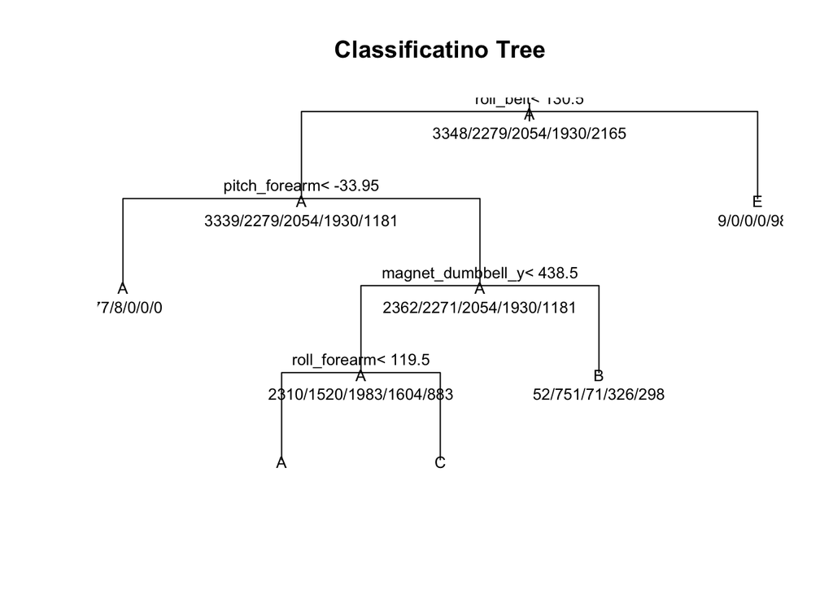

```r
plot(cartFit$finalModel, uniform=TRUE, main="Classificatino Tree")
text(cartFit$finalModel, use.n=TRUE, all=TRUE, cex=.8)
```

```r
predict_cartFit = predict(cartFit, testData)
table(predict_cartFit, testData$classe)
```

```
##
## predict_cartFit    A    B    C    D    E
##               A 2009  587  633  575  204
##               B   35  542   38  246  192
##               C  183  389  697  465  399
##               D    0    0    0    0    0
##               E    5    0    0    0  647
```

```r
accuracy_cartFit = postResample(predict_cartFit, testData$classe)
accuracy_cartFit
```

```
##  Accuracy     Kappa
## 0.4964313 0.3426350
```

Accuracy of CART model is 0.49.

## Random Forest Model

```r
RFFit <- randomForest(classe ~ ., data=trainData, importance=TRUE, proximity=TRUE)
RFFit
```

```
##
## Call:
##  randomForest(formula = classe ~ ., data = trainData, importance = TRUE,      proximity = TRUE)
##                Type of random forest: classification
##                      Number of trees: 500
## No. of variables tried at each split: 7
##
##         OOB estimate of  error rate: 0.67%
## Confusion matrix:
##      A    B    C    D    E class.error
## A 3344    1    1    1    1 0.001194743
## B   12 2262    5    0    0 0.007459412
## C    0   17 2034    3    0 0.009737098
## D    0    0   25 1903    2 0.013989637
## E    0    0    4    7 2154 0.005080831
```

```r
saveRDS(RFFit, "FR_file_v01.Rds")
```

Evaluate the prediction.

```r
predict_RF <- predict(RFFit, testData)
accuracy <- postResample(predict_RF, testData$classe)
accuracy
```

```
##  Accuracy     Kappa
## 0.9950293 0.9937121
```

```r
error <- 1 - as.numeric(confusionMatrix(testData$classe, predict_RF)$overall[1])
error
```

```
## [1] 0.004970686
```

The accuracy for Random Forest Model is 0.995 and the estimated out-of-sample error is 0.49%. So Random Forest model will be used for predicting the 20 testing cases.

In random forests, there is no need for cross-validation or a separate test set to get an unbiased estimate of the test set error. It is estimated internally.

# Predict for testing data

```r
#Remove the column named problem_id(last column))
result <- predict(RFFit, testing[, -length(names(testing))])
result
```

```
##  1  2  3  4  5  6  7  8  9 10 11 12 13 14 15 16 17 18 19 20
##  B  A  B  A  A  E  D  B  A  A  B  C  B  A  E  E  A  B  B  B
## Levels: A B C D E
```

# Submit the results using 20 files.

```r
answers <- result
pml_write_files <- function(x){
  n = length(x)
  for(i in 1:n){
    filename = paste0("problem_id_",i,".txt")
    i
    write.table(x[i], file=filename, quote=FALSE, row.names=FALSE, col.names=FALSE)
  }
}
pml_write_files(answers)
```